# Proyecto Final

Modelos Estadísticos Avanzados

Claudio Poveda, Tiffany Méndez, Valeria Chinchilla, Stephanie Rodriguez, Mariel Rodriguez

# 1 Introducción

El [dataset utlizado](https://www.kaggle.com/datasets/uradkr/ohio-sold-real-estate-intelligence-2026) proviene de Kaggle y fue recientemente publicado en el 2026. Contiene 21 columnas y +8 500 registros acerca de transacciones reales de ventas residenciales desde el año 1800 hasta el 2026 en Ohio, Estados Unidos. Incluye datos como el precio de venta, cantidad de baños y habitaciones, tamaño de la casa, año de venta, entre otros.

## 1.1 Objetivos

El objetivo de este proyecto es determinar el peso que tienen las variables en el precio final de las viviendas. También se busca encontrar grupos de residencias con comportamiento similar entre si y ser capaces de predecir su valor final en funcion de las demas variables

## 1.2 Pregunta de Analisis

¿Cómo influyen las características de las viviendas en su precio final en Ohio, qué agrupaciones naturales existen en el mercado y con qué precisión podemos predecir su valor?

## 1.3 Descripción de la base de datos

| Variable | Descripción | Valores |
| --- | --- | --- |
| `type` | Clasificacion arquitectonica de la propiedad. | `single_family`: Casa independiente e individual, pensada para una sola familia `condos`: Apartamentos individuales dentro de un solo edificio `townhomes`: Casas adosadas `multi_family`: Edificios com… |
| `sub_type` | No disponible | 100% nulos |
| `listPrice` | Precio inicial pedido por el vendedor en USD | Numericos |
| `sqft` | Superficie interior en pies cuadrados | Numericos |
| `stories` | Numero de pisos | Numericos |
| `beds` | Cantidad de dormitorios. Si la vivienda es `multi_family`, puede indicar la cantidad total de apartamentos | Numericos |
| `baths` | Conteo total de baños. Combina baños completos (inodoro + ducha + lavamanos) y baños de visitas (inodoro + lavamanos) | Numericos |
| `baths_full` | Cantidad de baños completos | Numericos |
| `baths_full_calc` | Cantidad de baños completos calclados por el sistema | Numericos |
| `garage` | Cantidad de autos que caben en el garage | Numericos |
| `lastSoldPrice` | Precio de venta final | Numericos |
| `postal_code` | Codigo postal de 5 digitos correspondiente a la propiedad | Numericos |
| `is_valid_oh_zip` | Indica si el codigo postal existe en Ohio | Todos sus valores son `True` |
| `zip_candidate_count` | Número de códigos postales de Ohio que el sistema encontró dentro del enlace web de la propiedad | Todos los valores son `1` |
| `sold_to_list_ratio` | Resultado de la division entre `lastSoldPrice` y `listPrice`. Si este valor es mayor a `1`, entonces indica que la casa se vendio por encima del precio original. | Numericos |
| `price_premium_pct` | Porcentaje de prima o descuento. Si es positivo indica que la propiedad se vendio por encima del precio original | Numericos |
| `negotiation_outcome` | Resultado de la negociacion | `At Asking`: La casa se vendió exactamente al precio listado `Above Asking`: La casa se vendió por más dinero del que pedía el vendedor `Below Asking`: El comprador obtuvo un descuento |
| `ratio_outlier_flag` | Indica si `sold_to_list_ratio` es un valor atipico | Booleano |
| `text_clean` | Descripción del texto publicitario de la propiedad | Cadenas de texto |
| `pii_redacted_flag` | Indica si el campo `text_clean` poseia informacion personal que fue censurada | Booleano |
| `year_built` | Año en que la propiedad fue construida | Numericos |

## 1.4 Carga de datos

Lo primero a realizar para la ejecucion de este proyecto es la carag de los datos por lo que se llama al dataset con un read.csv

```r
library(dplyr)

df = read.csv("ohio_sold_real_estate_intelligence_2026.csv")
df = df %>%
    select(-c(sub_type, is_valid_oh_zip, zip_candidate_count, text_clean, pii_redacted_flag)) %>%
    # Variables redundantes (marcadas en amarillo): nos quedamos con una por grupo
    # baths, baths_full, baths_full_calc -> nos quedamos con baths (conteo total, medida mas completa)
    # sold_to_list_ratio, price_premium_pct, negotiation_outcome -> nos quedamos con price_premium_pct (continua, mas informativa)
    select(-c(baths_full, baths_full_calc, sold_to_list_ratio, negotiation_outcome))

head(df, 3)
```

|  | type | listPrice | sqft | stories | beds | baths | garage | lastSoldPrice | postal_code | price_premium_pct | ratio_outlier_flag | year_built |
| --- | --- | --- | --- | --- | --- | --- | --- | --- | --- | --- | --- | --- |
| 1 | single_family | 115000 | 1328 | 2 | 4 | 2 | 2 | 115000 | 44017 | 0.000000 | False | 1893 |
| 2 | single_family | 359900 | 1864 | 2 | 4 | 3 | 2 | 365000 | 43125 | 1.417060 | False | 2018 |
| 3 | single_family | 237000 | 1600 | 1 | 3 | 2 | 1 | 235189 | 45015 | -0.764135 | False | 1927 |

## 1.5 Exploración y preparación de los datos

```r
library(tidyverse)
library(mice)
library(cluster)
library(factoextra)
library(ggcorrplot)
library(car)
library(olsrr)
library(fastDummies)
library(DescTools)
library(gvlma)



df$type = as.factor(df$type)
df$postal_code = as.factor(df$postal_code)
df$ratio_outlier_flag = as.logical(df$ratio_outlier_flag)

summary(df)
```

```
##             type        listPrice            sqft          stories
##  condos       : 875   Min.   :      1   Min.   :    1   Min.   : 1.000
##  multi_family : 209   1st Qu.: 199900   1st Qu.: 1324   1st Qu.: 1.000
##  other        :   5   Median : 289900   Median : 1734   Median : 2.000
##  single_family:7384   Mean   : 347207   Mean   : 2009   Mean   : 1.672
##  townhomes    :  50   3rd Qu.: 420000   3rd Qu.: 2400   3rd Qu.: 2.000
##                       Max.   :4950000   Max.   :13238   Max.   :20.000
##                                                         NA's   :173
##       beds             baths             garage        lastSoldPrice
##  Min.   :  0.000   Min.   :  1.000   Min.   :  1.000   Min.   :    164
##  1st Qu.:  3.000   1st Qu.:  2.000   1st Qu.:  2.000   1st Qu.: 199900
##  Median :  3.000   Median :  2.000   Median :  2.000   Median : 290000
##  Mean   :  3.258   Mean   :  2.422   Mean   :  2.051   Mean   : 347964
##  3rd Qu.:  4.000   3rd Qu.:  3.000   3rd Qu.:  2.000   3rd Qu.: 420000
##  Max.   :118.000   Max.   :108.000   Max.   :520.000   Max.   :4578000
##  NA's   :4         NA's   :24        NA's   :1350
##   postal_code   price_premium_pct   ratio_outlier_flag   year_built
##  43123  :  82   Min.   :     -100   Mode :logical      Min.   :1800
##  43015  :  75   1st Qu.:       -3   FALSE:7709         1st Qu.:1948
##  43081  :  73   Median :        0   TRUE :814          Median :1969
##  43026  :  68   Mean   :    51468                      Mean   :1968
##  45069  :  67   3rd Qu.:        2                      3rd Qu.:1997
##  43065  :  65   Max.   :153509200                      Max.   :2026
##  (Other):8093                                          NA's   :69
```

Se observan algunos valores imposibles y algunas variables con valores nulos

### 1.5.1 Tratamiento de valores atipicos

```r
extremos <- c("baths", "beds", "stories", "garage")

for (col in extremos) {
  cat("\n--- Columna:", col, "---\n")
  print(table(df[[col]]))
}
```

```
##
## --- Columna: baths ---
##
##    1    2    3    4    5    6    7    8    9   10   12  108
## 1574 3438 2341  853  210   55   15    7    3    1    1    1
##
## --- Columna: beds ---
##
##    0    1    2    3    4    5    6    7    8    9   10   11   12  118
##   19   72 1340 4229 2301  432   88   13   14    4    3    1    2    1
##
## --- Columna: stories ---
##
##    1    2    3    4    5   20
## 3181 4754  407    5    2    1
##
## --- Columna: garage ---
##
##    1    2    3    4    5    6    7    8   10   12   27   30  520
## 1632 4568  702  179   35   33    5   11    4    1    1    1    1
```

```r
df %>%
  filter(
    stories == max(stories, na.rm = TRUE) |
    beds   == max(beds, na.rm = TRUE) |
    baths    == max(baths , na.rm = TRUE) |
    garage   == max(garage, na.rm = TRUE)
  )
```

| type | listPrice | sqft | stories | beds | baths | garage | lastSoldPrice | postal_code | price_premium_pct | ratio_outlier_flag | year_built |
| --- | --- | --- | --- | --- | --- | --- | --- | --- | --- | --- | --- |
| single_family | 159900 | 1156 | 20 | 3 | 1 | NA | 155000 | 44512 | -3.064415 | FALSE | 1934 |
| single_family | 2200 | 1272 | 1 | 118 | 108 | NA | 2000 | 45365 | -9.090909 | FALSE | 1968 |
| single_family | 99900 | 970 | 2 | 3 | 2 | 520 | 95000 | 43607 | -4.904905 | FALSE | 1951 |

Los valores maximos de las columnas anteriormente mostradas muestran valores imposibles. Ademas, al analizar su contenido se aprecia como los demas campos no tienen sentido.

```r
df <- df %>%
  filter(
    coalesce(
      !(stories == max(stories, na.rm = TRUE) |
        beds    == max(beds, na.rm = TRUE)    |
        baths   == max(baths, na.rm = TRUE)   |
        garage  == max(garage, na.rm = TRUE)),
      TRUE
    ),

    coalesce(listPrice >= 10000, TRUE),
    coalesce(lastSoldPrice >= 10000, TRUE),
    coalesce(sqft >= 150, TRUE),
    coalesce(price_premium_pct <= 100, TRUE)
  )
```

### 1.5.2 Visualizacion de variables numericas

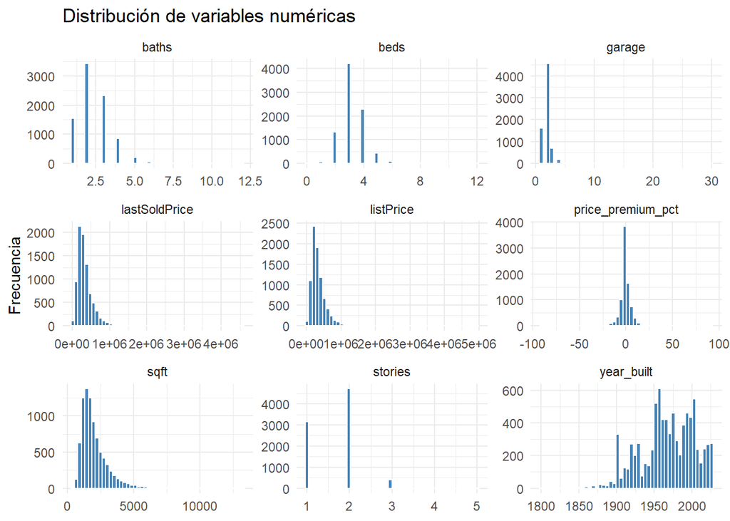

```r
df %>%
  select(where(is.numeric)) %>%
  pivot_longer(cols = everything(), names_to = "Variable", values_to = "Valor") %>%
  ggplot(aes(x = Valor)) +
  geom_histogram(bins = 50, fill = "steelblue", color = "white") +
  facet_wrap(~ Variable, scales = "free") +
  theme_minimal() +
  labs(title = "Distribución de variables numéricas",
       x = NULL,
       y = "Frecuencia")
```

Se observan valores extremos que provocan grandes sesgos en la distribucion de los graficos.

### 1.5.3 Correlaciones

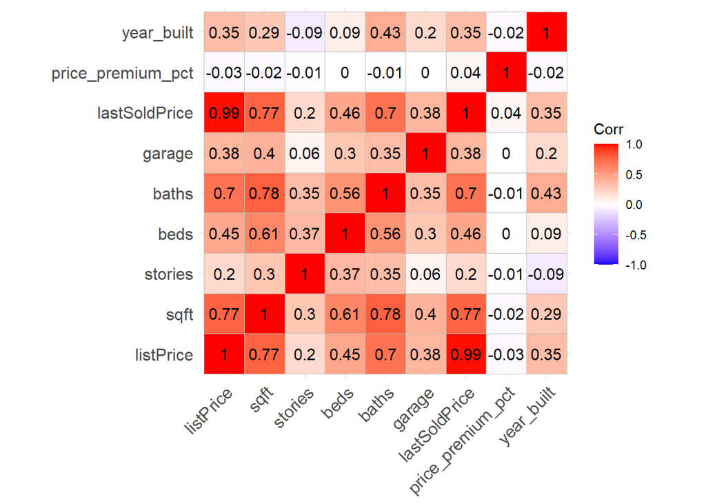

```r
cor_matrix <- cor(df[sapply(df, is.numeric)], use = "complete.obs")
ggcorrplot(cor_matrix, type = "full", lab = TRUE)
```

La matriz de correlación reveló que todas las relaciones fuertes identificadas son positivas. La correlación más alta se observa, como es esperable, entre lastSoldPrice y listPrice, dado que ambas variables están directamente relacionadas el precio final suele negociarse a partir del precio de lista. Las variables sqft y baths también mostraron una relación importante con lastSoldPrice, lo que sugiere que el tamaño de la vivienda y la cantidad de baños son factores relevantes para explicar el precio final.

### 1.5.4 Imputacion de valores nulos

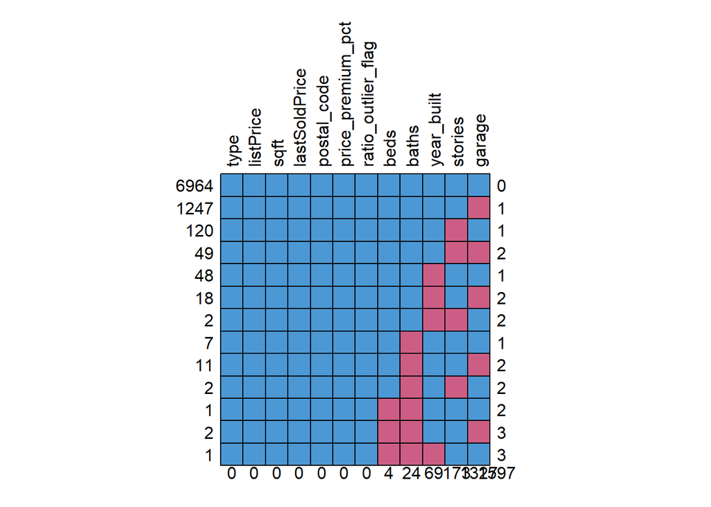

```r
invisible(md.pattern(df, rotate.names = TRUE))
```

No se observa un patron marcado en los datos faltantes, por lo que probablemente se trate de un MCAR.

```r
ini = mice(df, max = 0, print = FALSE)
predMatrix = ini$predictorMatrix
metodos = ini$method

predMatrix[, "postal_code"] = 0
predMatrix[, "price_premium_pct"] = 0

set.seed(123)
imputacion_mice = mice(
  data = df,
  m = 5,
  predictorMatrix = predMatrix,
  method = metodos,
  printFlag = FALSE
)

df_imputado <- complete(imputacion_mice, 1)
```

```r
nulos <- data.frame(
  cantidad = sapply(df_imputado, function(x) sum(is.na(x))),
  porcentaje = sapply(df_imputado, function(x) round(mean(is.na(x)) * 100, 3))
)

cat(nulos['cantidad'] %>% sum())
```

```
## 0
```

```r
print(nulos)
```

```
##                    cantidad porcentaje
## type                      0          0
## listPrice                 0          0
## sqft                      0          0
## stories                   0          0
## beds                      0          0
## baths                     0          0
## garage                    0          0
## lastSoldPrice             0          0
## postal_code               0          0
## price_premium_pct         0          0
## ratio_outlier_flag        0          0
## year_built                0          0
```

Como las variables numéricas están correlacionadas entre sí, se optó por imputación múltiple mediante el algoritmo MICE ya que aprovecha esas relaciones entre variables para generar estimaciones más precisas y evita sesgos

Durante la revisión inicial se identificaron varias columnas que no aportan valor real y fueron descartadas estas fueron: sub_type (100% de valores nulos) is_valid_oh_zip y zip_candidate_count (constantes, sin variabilidad) text_clean y pii_redacted_flag (texto libre no estructurado)

Tambien se detectaron grupos de variables redundantes entre sí, de los cuales se conservó una sola representante por grupo: de baths baths_full y baths_full_calc se mantuvo baths por ser la medida más completa; de sold_to_list_ratio, price_premium_pct y negotiation_outcome se mantuvo price_premium_pct por ser continua y más informativa que sus alternativas.

Al inspeccionar las variables beds, baths, stories y garage se encontraron valores físicamente imposibles para una vivienda residencial, como garajes con capacidad para 520 vehículos, 108 baños o 118 dormitorios en un mismo inmueble. Al revisar el resto de los campos de esos registros se confirmó que no tenían sentido en su conjunto, por lo que se decidió eliminarlos del análisis.

Además de este filtro, se aplicaron umbrales mínimos razonables a otras variables de precio y tamaño: se excluyeron registros con listPrice o lastSoldPrice menores a $10 000 USD, viviendas con menos de 150 pies cuadrados de superficie, y valores de price_premium_pct superiores al 100%, todos ellos indicativos de errores de captura o de transacciones no representativas del mercado residencial típico.

## 1.6 Clustering

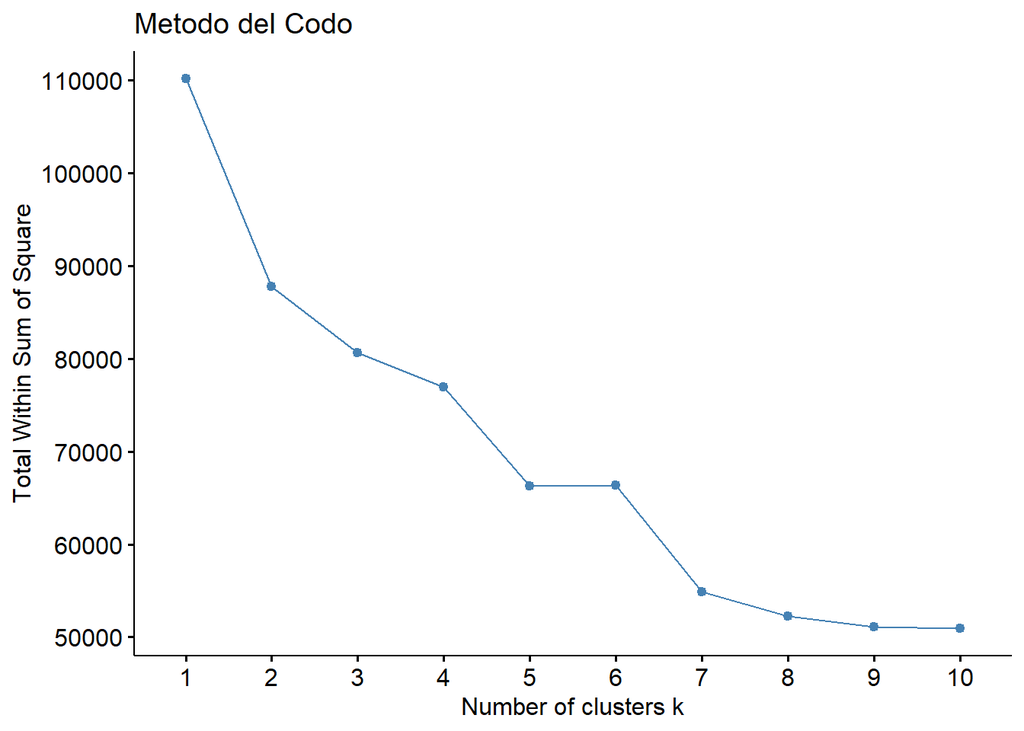

```r
df_base <- df_imputado %>%
  select(-c(postal_code, listPrice)) %>%
  mutate(across(
    where(is.numeric), ~ Winsorize(.x, val = quantile(.x, probs = c(0.1, 0.9))))) %>%
  dummy_cols(select_columns = 'type', remove_selected_columns = TRUE, remove_first_dummy = TRUE) %>%
  mutate(ratio_outlier_flag = as.integer(ratio_outlier_flag))

df_clustering = df_base %>%
  scale()

set.seed(123)
fviz_nbclust(df_clustering, kmeans, method = "wss") +
  labs(title = "Metodo del Codo")
```

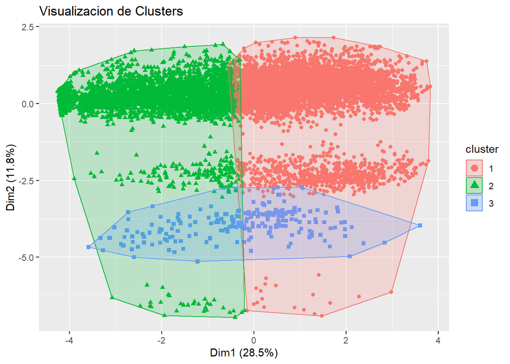

```r
set.seed(123)
k <- 3

km_res <- kmeans(df_clustering, centers = k, nstart = 25)

fviz_cluster(km_res, data = df_clustering, geom = "point", ellipse.type = "convex") +
  labs(title = "Visualizacion de Clusters")
```

```r
df_base %>%
  mutate(cluster = km_res$cluster) %>%
  group_by(cluster) %>%
  summarise(
    count = n(),
    across(where(is.numeric), ~ round(mean(.x, na.rm = TRUE), 2))
  )
```

| cluster | count | sqft | stories | beds | baths | garage | lastSoldPrice | price_premium_pct | ratio_outlier_flag | year_built | type_multi_family | type_other | type_single_family | type_townhomes |
| --- | --- | --- | --- | --- | --- | --- | --- | --- | --- | --- | --- | --- | --- | --- |
| 1 | 5118 | 1470.58 | 1.48 | 2.85 | 1.81 | 1.63 | 237433.5 | -0.22 | 0.11 | 1958.74 | 0.00 | 0.00 | 0.86 | 0.00 |
| 2 | 3141 | 2623.18 | 1.84 | 3.65 | 3.25 | 2.24 | 473963.0 | -0.05 | 0.05 | 1987.98 | 0.00 | 0.00 | 0.94 | 0.01 |
| 3 | 213 | 2413.98 | 1.90 | 3.73 | 2.60 | 2.11 | 243645.5 | -1.77 | 0.20 | 1936.96 | 0.98 | 0.02 | 0.00 | 0.00 |

## 1.7 Regresion Lineal Multiple

```r
df_lm = df_base %>%
  select(-c(price_premium_pct, ratio_outlier_flag))

regresion <- df_lm %>%
  lm(lastSoldPrice ~ ., data = .)

summary(regresion)
```

```
##
## Call:
## lm(formula = lastSoldPrice ~ ., data = .)
##
## Residuals:
##     Min      1Q  Median      3Q     Max
## -312859  -51816   -6987   40961  462691
##
## Coefficients:
##                      Estimate Std. Error t value Pr(>|t|)
## (Intercept)        -1.867e+06  7.765e+04 -24.050  < 2e-16 ***
## sqft                1.013e+02  2.250e+00  45.015  < 2e-16 ***
## stories            -3.524e+03  2.224e+03  -1.584 0.113127
## beds               -4.722e+03  1.907e+03  -2.476 0.013312 *
## baths               3.853e+04  1.722e+03  22.378  < 2e-16 ***
## garage              2.308e+04  1.863e+03  12.389  < 2e-16 ***
## year_built          9.420e+02  3.947e+01  23.868  < 2e-16 ***
## type_multi_family  -8.784e+04  7.393e+03 -11.881  < 2e-16 ***
## type_other          1.379e+05  3.839e+04   3.593 0.000328 ***
## type_single_family  3.670e+04  3.623e+03  10.131  < 2e-16 ***
## type_townhomes      3.496e+04  1.244e+04   2.811 0.004951 **
## ---
## Signif. codes:  0 '***' 0.001 '**' 0.01 '*' 0.05 '.' 0.1 ' ' 1
##
## Residual standard error: 85210 on 8461 degrees of freedom
## Multiple R-squared:  0.6843, Adjusted R-squared:  0.6839
## F-statistic:  1834 on 10 and 8461 DF,  p-value: < 2.2e-16
```

```r
vif(regresion)
```

```
##               sqft            stories               beds              baths
##           3.064354           1.357621           2.017065           3.003350
##             garage         year_built  type_multi_family         type_other
##           1.488099           1.712119           1.527247           1.014060
## type_single_family     type_townhomes
##           1.776683           1.058987
```

Se observa como la variable ‘stories’ es la unica que practicamente no tiene importancia en el modelo. Ademas, el VIF nos indica que no hay problemas de multicolinealidad

```r
full_model <- lm(
  lastSoldPrice ~ sqft + beds + baths + garage + year_built + type_multi_family + type_other  + type_single_family,
  data = df_lm
)

all_models <- ols_step_all_possible(full_model)

all_models$result %>%
  as_tibble() %>%
  arrange(desc(adjr)) %>%
  head(10)
```

| mindex | n | predictors | rsquare | adjr | rmse | predrsq | cp | aic | sbic | sbc | msep | fpe | apc | hsp |
| --- | --- | --- | --- | --- | --- | --- | --- | --- | --- | --- | --- | --- | --- | --- |
| 255 | 8 | sqft beds baths garage year_built type_multi_family type_other type_single_family | 0.6839194 | 0.6836206 | 85207.59 | 0.6830947 | 9.00000 | 216425.1 | 192382.6 | 216495.6 | 6.157496e+13 | 7275775655 | 0.3167529 | 858905.1 |
| 247 | 7 | sqft baths garage year_built type_multi_family type_other type_single_family | 0.6836345 | 0.6833728 | 85245.99 | 0.6828982 | 14.62938 | 216430.7 | 192388.3 | 216494.1 | 6.162319e+13 | 7280615798 | 0.3169636 | 859476.2 |
| 248 | 7 | sqft beds baths garage year_built type_multi_family type_single_family | 0.6834504 | 0.6831886 | 85270.78 | 0.6827715 | 19.55686 | 216435.7 | 192393.2 | 216499.1 | 6.165904e+13 | 7284851032 | 0.3171480 | 859976.2 |
| 219 | 6 | sqft baths garage year_built type_multi_family type_single_family | 0.6832020 | 0.6829774 | 85304.24 | 0.6826096 | 24.20900 | 216440.3 | 192397.8 | 216496.7 | 6.170014e+13 | 7288847741 | 0.3173220 | 860447.8 |
| 249 | 7 | sqft beds baths garage year_built type_multi_family type_other | 0.6802279 | 0.6799634 | 85703.72 | 0.6794733 | 105.84055 | 216521.5 | 192478.8 | 216584.9 | 6.228675e+13 | 7359012984 | 0.3203766 | 868731.0 |
| 220 | 6 | sqft baths garage year_built type_multi_family type_other | 0.6801876 | 0.6799609 | 85709.12 | 0.6795171 | 104.91871 | 216520.6 | 192477.9 | 216576.9 | 6.228723e+13 | 7358202404 | 0.3203413 | 868635.1 |
| 221 | 6 | sqft beds baths garage year_built type_multi_family | 0.6799949 | 0.6797681 | 85734.93 | 0.6793877 | 110.07796 | 216525.7 | 192483.0 | 216582.0 | 6.232476e+13 | 7362635805 | 0.3205343 | 869158.5 |
| 163 | 5 | sqft baths garage year_built type_multi_family | 0.6799519 | 0.6797629 | 85740.69 | 0.6794302 | 109.22886 | 216524.8 | 192482.2 | 216574.1 | 6.232577e+13 | 7361886645 | 0.3205017 | 869069.9 |
| 250 | 7 | sqft beds baths garage year_built type_other type_single_family | 0.6784119 | 0.6781460 | 85946.73 | 0.6776617 | 154.46207 | 216569.5 | 192526.7 | 216632.9 | 6.264046e+13 | 7400803809 | 0.3221960 | 873664.4 |
| 251 | 7 | sqft beds baths year_built type_multi_family type_other type_single_family | 0.6780129 | 0.6777466 | 86000.04 | 0.6772621 | 165.14680 | 216580.0 | 192537.2 | 216643.4 | 6.271820e+13 | 7409987474 | 0.3225958 | 874748.5 |

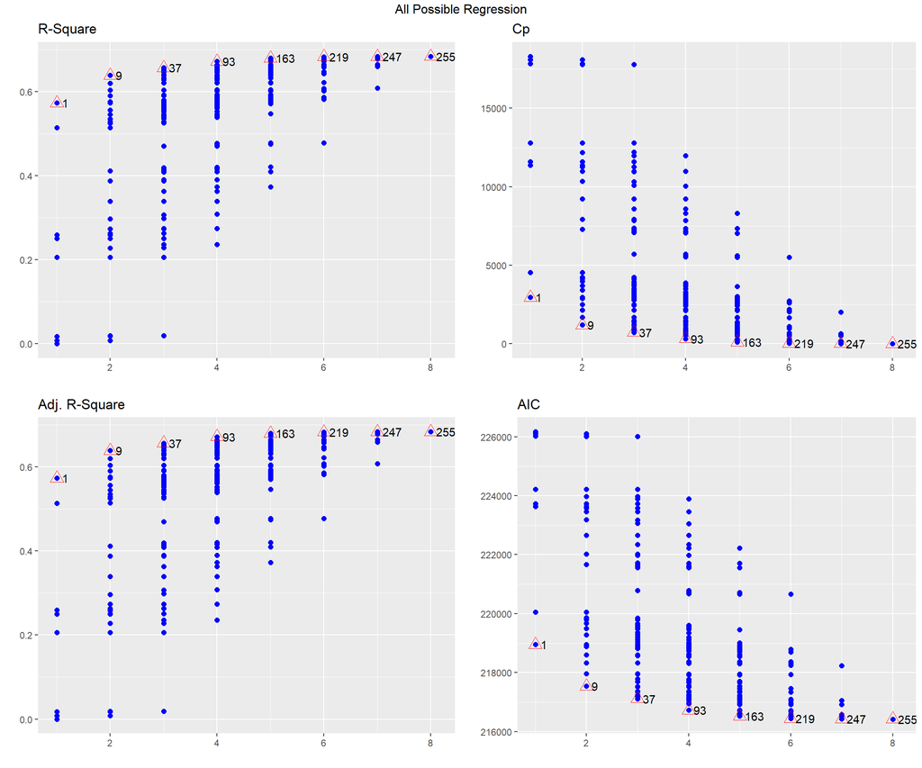

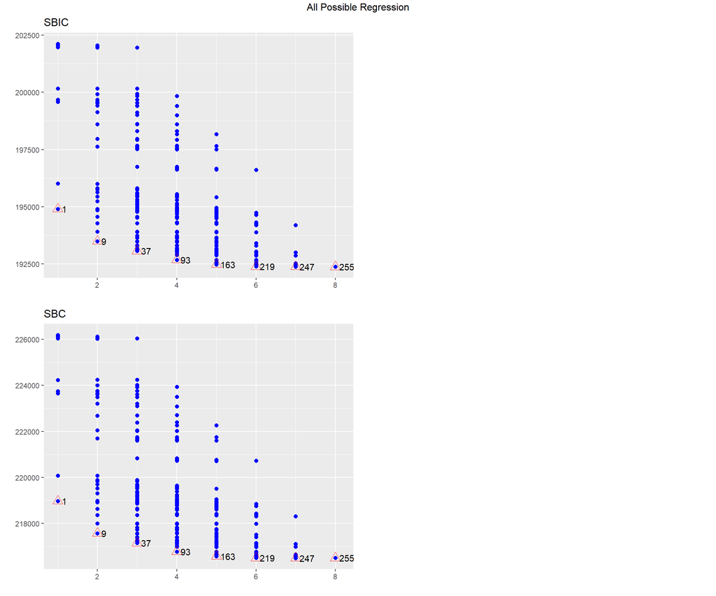

```r
plot(all_models)
```

```r
lm_final =   lm(lastSoldPrice ~sqft+ beds+ baths+ garage+ year_built+ type_multi_family+ type_other, data = df_lm)
summary(gvlma(lm_final))
```

```
##
## Call:
## lm(formula = lastSoldPrice ~ sqft + beds + baths + garage + year_built +
##     type_multi_family + type_other, data = df_lm)
##
## Residuals:
##     Min      1Q  Median      3Q     Max
## -313393  -52427   -6836   43284  473105
##
## Coefficients:
##                     Estimate Std. Error t value Pr(>|t|)
## (Intercept)       -1.693e+06  7.084e+04 -23.900   <2e-16 ***
## sqft               1.024e+02  2.252e+00  45.463   <2e-16 ***
## beds               1.798e+03  1.742e+03   1.032    0.302
## baths              3.533e+04  1.671e+03  21.147   <2e-16 ***
## garage             2.630e+04  1.845e+03  14.252   <2e-16 ***
## year_built         8.566e+02  3.641e+01  23.523   <2e-16 ***
## type_multi_family -1.288e+05  6.220e+03 -20.701   <2e-16 ***
## type_other         9.535e+04  3.840e+04   2.483    0.013 *
## ---
## Signif. codes:  0 '***' 0.001 '**' 0.01 '*' 0.05 '.' 0.1 ' ' 1
##
## Residual standard error: 85740 on 8464 degrees of freedom
## Multiple R-squared:  0.6802, Adjusted R-squared:   0.68
## F-statistic:  2572 on 7 and 8464 DF,  p-value: < 2.2e-16
##
##
## ASSESSMENT OF THE LINEAR MODEL ASSUMPTIONS
## USING THE GLOBAL TEST ON 4 DEGREES-OF-FREEDOM:
## Level of Significance =  0.05
##
## Call:
##  gvlma(x = lm_final)
##
##                        Value p-value                   Decision
## Global Stat        1.922e+03  0.0000 Assumptions NOT satisfied!
## Skewness           6.436e+02  0.0000 Assumptions NOT satisfied!
## Kurtosis           1.162e+03  0.0000 Assumptions NOT satisfied!
## Link Function      1.167e+02  0.0000 Assumptions NOT satisfied!
## Heteroscedasticity 7.543e-03  0.9308    Assumptions acceptable.
```

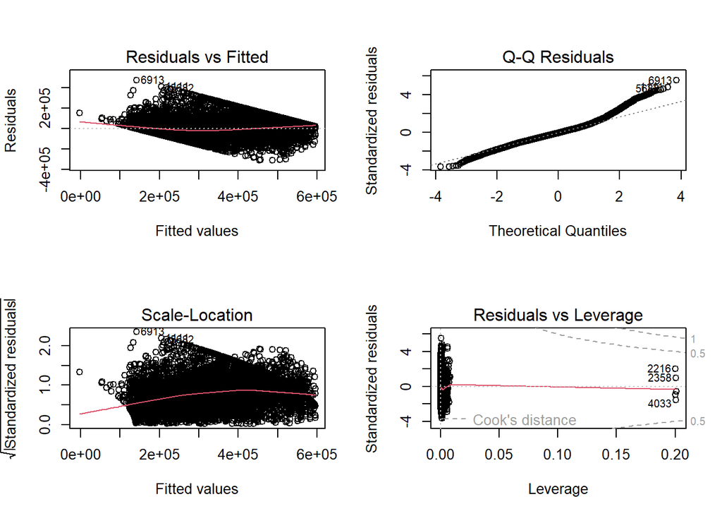

```r
par(mfrow=c(2,2))
plot(lm_final)
```

El objetivo de esta etapa es predecir la variable lastSoldPrice a partir de las características físicas de la vivienda. Se excluyeron del modelo las variables derivadas directamente del precio, para evitar fuga de información (data leakage), y se partió de un modelo con todas las variables predictoras disponibles.

El resultado del modelo completo mostró que la variable stories es prácticamente irrelevante para explicar el precio final, con un aporte marginal no significativo. El análisis del Factor de Inflación de la Varianza confirmó que no existen problemas relevantes de multicolinealidad entre los predictores, es decir, las variables explicativas no están redundando información entre sí de forma problemática. se utilizó una búsqueda exhaustiva de todas las combinaciones posibles de predictores (ols_step_all_possible), evaluando su desempeño mediante el R² ajustado. Los resultados mostraron que los mejores modelos utilizan entre 7 y 8 variables con diferencias marginales de desempeño entre ellos.

El modelo final logra explicar aproximadamente el 68% de la variabilidad del precio de venta R² ≈ 0.68. Sin embargo, la validación de supuestos del modelo lineal indicó que no se cumplen todos los supuestos requeridos para una regresión lineal clásica, lo que limita la confiabilidad de las inferencias estadísticas estrictas del modelo.

En conclusion si bien el modelo lineal ofrece una primera aproximación razonable e interpretable sobre los factores que determinan el precio de una vivienda, el incumplimiento de los supuestos sugiere que sería conveniente explorar modelos alternativos que no dependen de estos supuestos y suelen capturar mejor relaciones no lineales entre las variables.

## 1.8 Montecarlo

```r
# Montecarlo

# ---- 1. Probabilidad base: proporción real de ventas sobre precio de lista ----
p_real <- mean(df$price_premium_pct > 0)
p_real
```

```
## [1] 0.388102
```

```r
# ---- 2. Simulación de Montecarlo ----
set.seed(309)

n <- 15       # tamaño de muestra (casas vendidas)
umbral <- 8   # al menos 8 de 15 por encima del precio de lista

N <- 10000
resultados <- logical(N)

for (i in 1:N) {
  ventas <- sample(c(TRUE, FALSE), size = n, replace = TRUE, prob = c(p_real, 1 - p_real))
  resultados[i] <- sum(ventas) >= umbral
}

p_estimada <- sum(resultados) / N
cat("Estimada:", round(100 * p_estimada, 1), "%\n")
```

```
## Estimada: 18.8 %
```

```r
# ---- 3. Probabilidad exacta (binomial) ----
p_exacta <- 1 - pbinom(umbral - 1, size = n, prob = p_real)
cat("Exacta: ", round(100 * p_exacta, 1), "%\n")
```

```
## Exacta:  18.6 %
```

```r
cat("Diferencia: ", round(100 * abs(p_estimada - p_exacta), 2), "puntos\n")
```

```
## Diferencia:  0.15 puntos
```

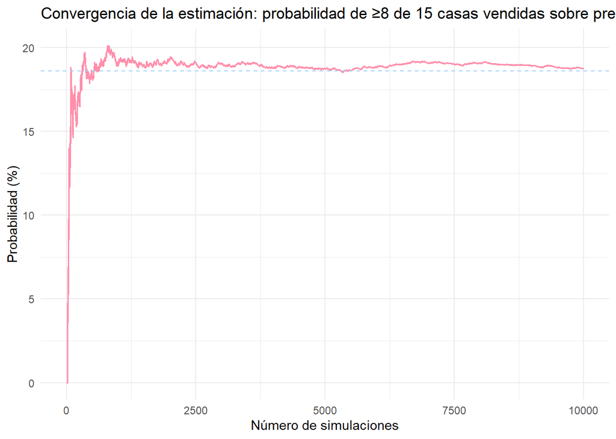

```r
# ---- 4. Gráfico de convergencia ----
library(ggplot2)

prop_acumulada <- cumsum(resultados) / (1:N)
datos <- data.frame(n_sim = 1:N, prob = 100 * prop_acumulada)

ggplot(datos, aes(x = n_sim, y = prob)) +
  geom_line(color = "#ff8fab", linewidth = 0.7) +
  geom_hline(yintercept = 100 * p_exacta, linetype = "dashed", color = "#a2d2ff") +
  labs(title = "Convergencia de la estimación: probabilidad de ≥8 de 15 casas vendidas sobre precio de lista",
       x = "Número de simulaciones", y = "Probabilidad (%)") +
  theme_minimal()
```

Los hallazgos del análisis sugieren que el precio de una vivienda en Ohio está determinado principalmente por su tamaño y su cantidad de baños, mientras que variables como el número de pisos aportan poca información adicional una vez que se controla por el resto de las características. Esto es consistente con la intuición de mercado: los compradores valoran directamente el espacio habitable y la funcionalidad de los baños, mientras que la distribución en pisos es en gran medida una consecuencia del tamaño del lote y no un atributo independiente que se pague por sí mismo.

En cuanto al modelo de regresión, que explica cerca del 68% de la variabilidad del precio, el resultado indica que las variables estructurales de la vivienda capturan una parte sustancial de lo que determina el precio final. El 32% restante de la variabilidad probablemente esté asociado a factores no incluidos en la base de datos, como la ubicación específica dentro del código postal, el estado de conservación de la propiedad, condiciones del mercado en el momento de la venta, o características cualitativas que no fueron capturadas como variables numéricas.

## 1.9 Limitaciones

Eliminación de outliers basada en criterios manuales:

los umbrales utilizados para descartar registros imposibles como por ejemplo precios mínimos o baños máximos no fueron mediante un método estadístico formal, lo que introduce cierto grado de subjetividad en los datos finalmente analizados.

Incumplimiento de los supuestos de la regresión lineal:

la prueba gvlma indicó que no se cumplen todos los supuestos clásicos del modelo, por lo que los errores estándar, los intervalos de confianza y las pruebas de significancia del modelo deben interpretarse con cautela, el modelo es útil como aproximación descriptiva y predictiva, pero no garantiza inferencia estadística rigurosa.

el recorte de valores extremos entre los percentiles :

el recorte de valores extremos entre los percentiles 10 y 90 reduce la influencia de outliers, pero también implica que el modelo y los clusters no representan bien a las propiedades verdaderamente atípicas del mercado

Alcance geográfico y temporal:

al tratarse de datos exclusivos del estado de Ohio, los resultados y el modelo no son necesariamente generalizables a otros mercados inmobiliarios con dinámicas de precio distintas.